```python
import pandas as pd
import numpy as np
import matplotlib.pyplot as plt
import seaborn as sns
```

# Данные

# Task 1

```python
headers = {0 : 'date',
           1 : 'timestamp',
           2 : 'name',
           3 : 'params_key',
           4 : 'string_value',
           5 : 'int_value',
           6 : 'value_revenue',
           7 : 'user'}

df = pd.read_csv('task_1_1.csv', encoding = "ISO-8859-1", sep=';', error_bad_lines=False, header=None)
df.rename(columns=headers, inplace=True)
df.info()
```

```
<class 'pandas.core.frame.DataFrame'>
RangeIndex: 2790096 entries, 0 to 2790095
Data columns (total 8 columns):
date             int64
timestamp        int64
name             object
params_key       object
string_value     object
int_value        float64
value_revenue    float64
user             object
dtypes: float64(2), int64(2), object(4)
memory usage: 170.3+ MB
```

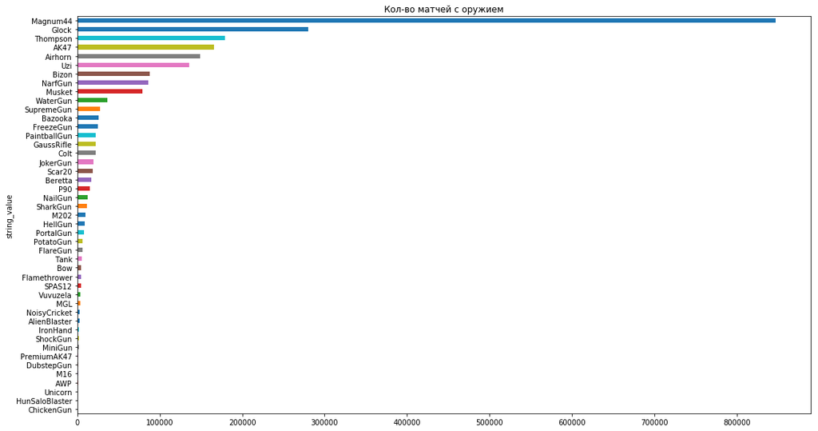

```python
fig, ax = plt.subplots(figsize=[18, 10])
df[df['name'] == 'match_start'].groupby('string_value')['user'].count().sort_values().plot(kind='barh');
ax.set_title('Кол-во матчей с оружием');
```

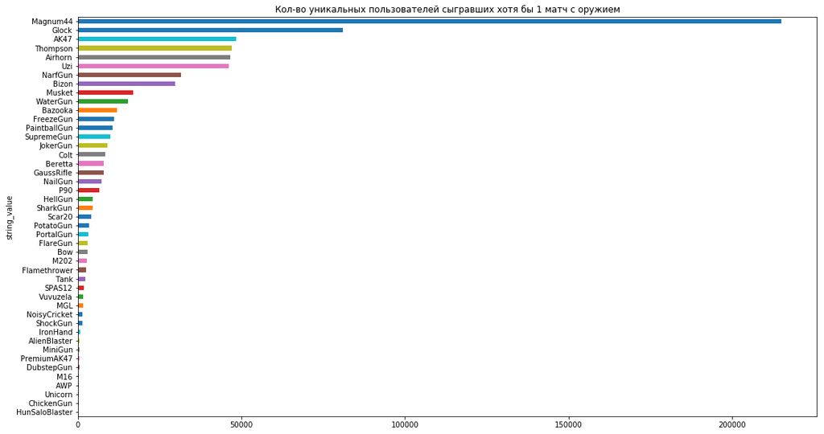

```python
fig, ax = plt.subplots(figsize=[18, 10])
df[df['name'] == 'match_start'].groupby('string_value')['user'].nunique().sort_values().plot(kind='barh', ax=ax);
ax.set_title('Кол-во уникальных пользователей сыгравших хотя бы 1 матч с оружием');
```

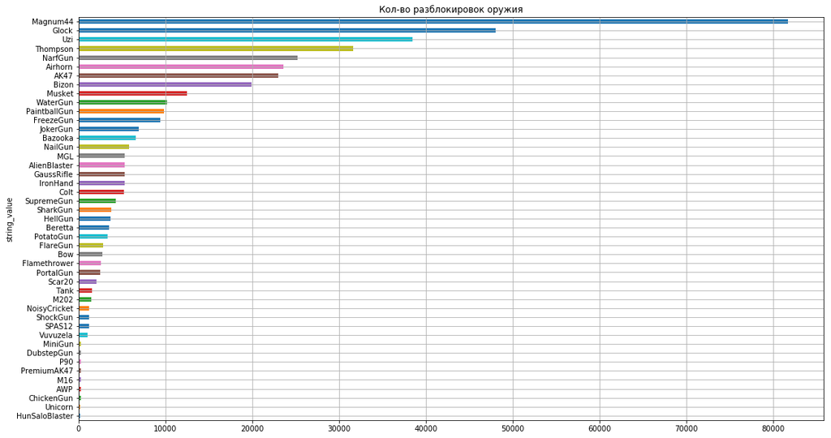

```python
fig, ax = plt.subplots(figsize=[18, 10])
df[df['name'] == 'unlock_content'].groupby('string_value')['user'].count().sort_values().plot(kind='barh', ax=ax);
ax.grid()
ax.set_title('Кол-во разблокировок оружия');
```

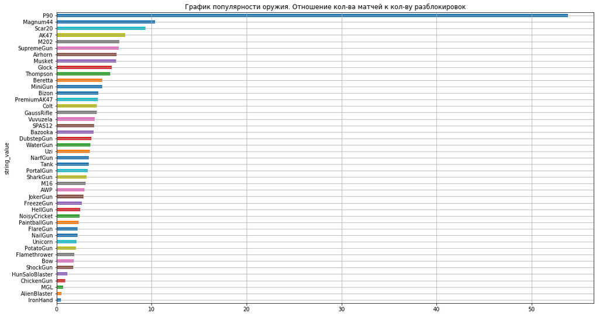

```python
df_temp = df[df['name'] == 'match_start'].groupby('string_value')['user'].count().to_frame()
df_temp = df_temp.join(other=df[df['name'] == 'unlock_content'].groupby('string_value')['name'].count().to_frame(),
                       on='string_value', lsuffix='l_', rsuffix='r_')
df_temp.rename(columns={'user' : 'number_of_match', 'name' : 'number_of_unlocks'}, inplace=True)
df_temp['koeff_popular'] = df_temp.number_of_match / df_temp.number_of_unlocks


fig, ax = plt.subplots(figsize=[18,10])
df_temp['koeff_popular'].sort_values().plot(kind='barh', ax=ax);
ax.grid()
ax.set_title('График популярности оружия. Отношение кол-ва матчей к кол-ву разблокировок');
```

- 1) Топ по кол-ву сыграных матчей с оружием
- 2) Топ по кол-ву сыграных матчей с оружием (уникальные пользователи)
- 3) Топ по кол-ву разблокировок оружия
- 4) Рейтинг популярности оружия (отношение кол-ва матчей к кол-ву разблокировок)
- Кол-во матчей с глоком больше, чем с ак47 и томпсоном, следовательно первоначально пользователь не знает о том, что ему доступны поумолчанию другие виды оружия.
- Самое популярное оружие (по коэфф.) Р90 - значит пользователям он нравится(возможно из-за хорошей физики), но кол-во разблокировок остается маленьким(продается только в пакете). Возможно выброс.

# Task 2

```python
headers = {0 : 'date',
           1 : 'timestamp',
           2 : 'name',
           3 : 'params_key',
           4 : 'string_value',
           5 : 'int_value',
           6 : 'value_revenue',
           7 : 'user'}

df = pd.read_csv('task_2.csv', encoding = "ISO-8859-1", sep=';', error_bad_lines=False, header=None)
df.rename(columns=headers, inplace=True)
df.info()
```

[output not shown]

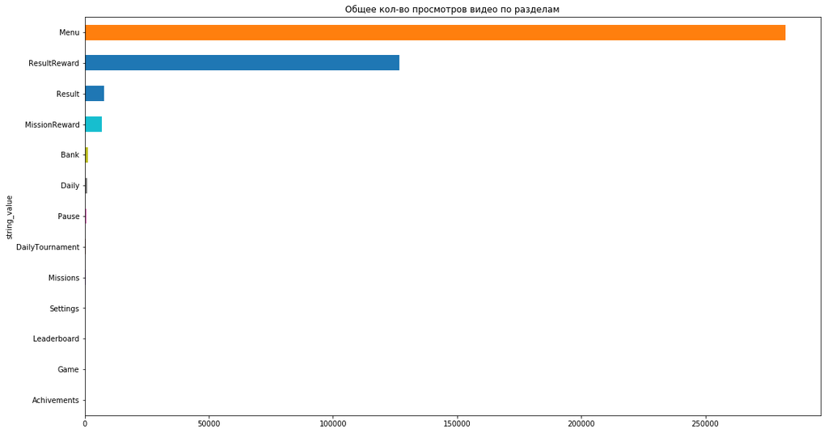

```python
fig, ax = plt.subplots(figsize=[18, 10])
df.groupby('string_value')['user'].count().sort_values().plot(kind='barh');
ax.set_title('Общее кол-во просмотров видео по разделам');
```

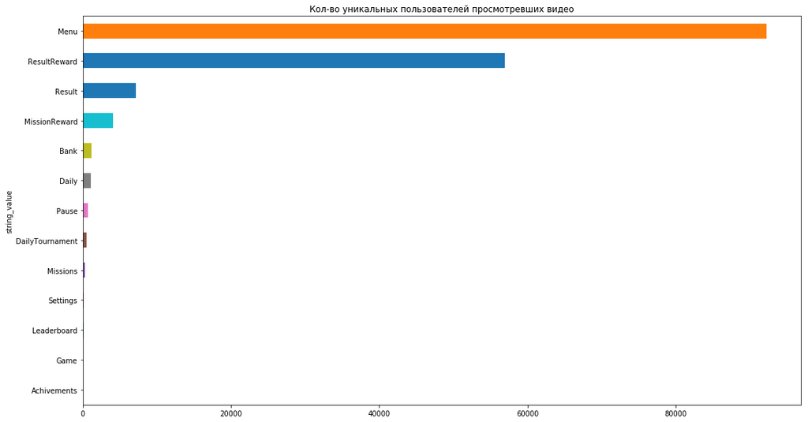

```python
fig, ax = plt.subplots(figsize=[18, 10])
df.groupby('string_value')['user'].nunique().sort_values().plot(kind='barh', ax=ax);
ax.set_title('Кол-во уникальных пользователей просмотревших видео');
```

- из графиков следуют, что в основном пользователи смотрят видео чтобы получить новое оружие или увеличить количество монеток в вознаграждении

# Task 3

```python
headers = {0 : 'date',
           1 : 'timestamp',
           2 : 'name',
           3 : 'params_key',
           4 : 'string_value',
           5 : 'int_value',
           6 : 'value_revenue',
           7 : 'user'}

df = pd.read_csv('task_3.csv', encoding = "ISO-8859-1", sep=';', error_bad_lines=False, header=None)
df.rename(columns=headers, inplace=True)
df.info()
```

```
<class 'pandas.core.frame.DataFrame'>
RangeIndex: 841256 entries, 0 to 841255
Data columns (total 8 columns):
date             841256 non-null int64
timestamp        841256 non-null int64
name             841256 non-null object
params_key       841256 non-null object
string_value     821053 non-null object
int_value        0 non-null float64
value_revenue    841255 non-null float64
user             841255 non-null object
dtypes: float64(2), int64(2), object(4)
memory usage: 51.3+ MB
```

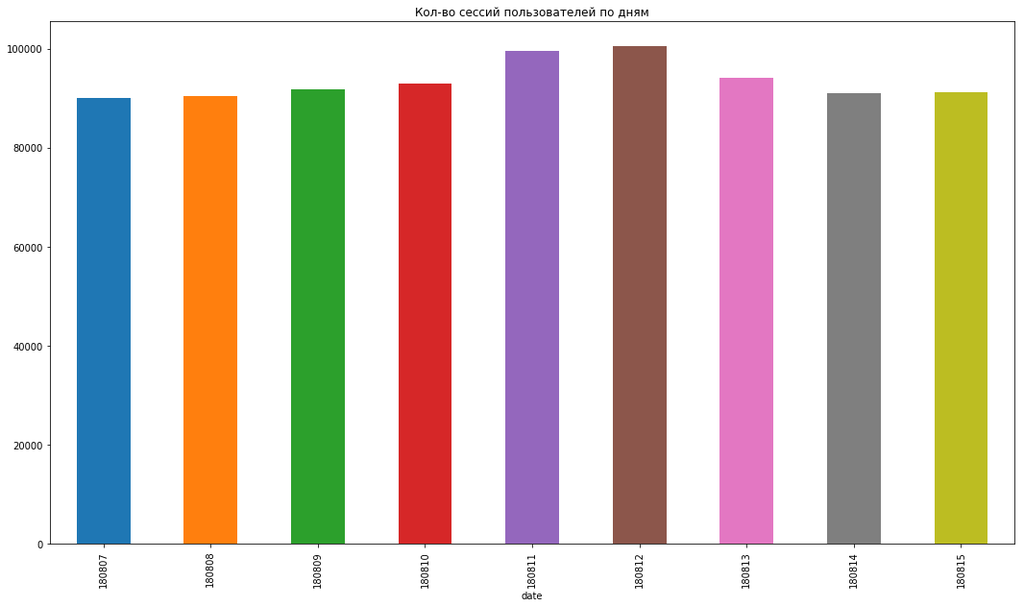

```python
fig, ax = plt.subplots(figsize=[18, 10])
df.groupby('date')['user'].count().plot(kind='bar', ax=ax);
ax.set_title('Кол-во сессий пользователей по дням');
```

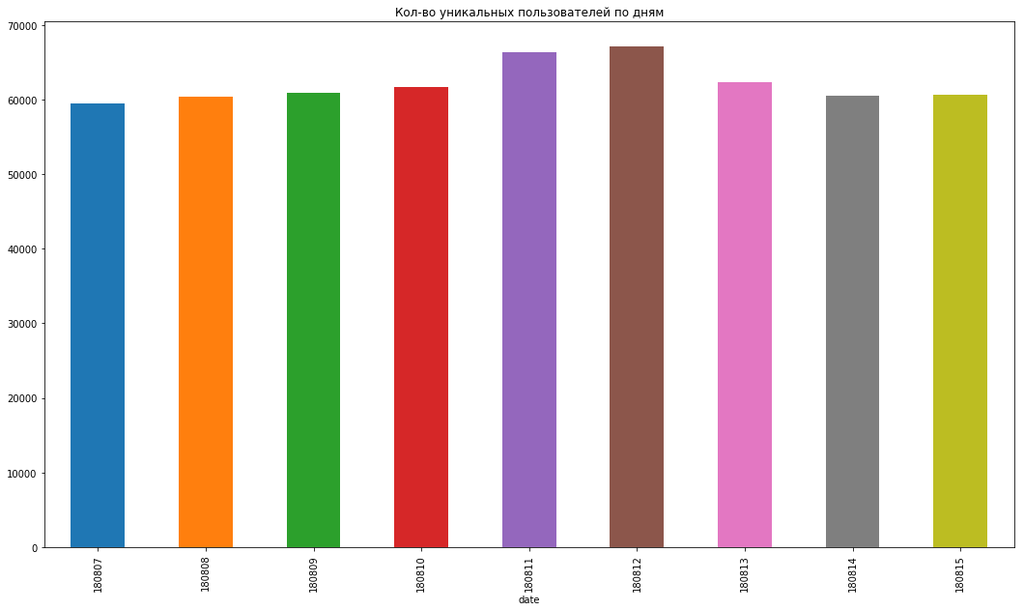

```python
fig, ax = plt.subplots(figsize=[18, 10])
df.groupby('date')['user'].nunique().plot(kind='bar', ax=ax);
ax.set_title('Кол-во уникальных пользователей по дням');
```

[figure not shown]

```python
df_temp = df.groupby('user')['name'].count().to_frame()

fig, ax = plt.subplots(figsize=[18, 10])
df_temp.groupby('name')['name'].count().plot(kind='bar', ax=ax)
ax.set_title('Кол-во пользователей по кол-ву сессий за неделю');
ax.set_xlabel('Кол-во сессий');
```

- Выходные дни в среднем на 10% чаще посещаемые игроками
- По графику с кол-вом сессий на игрока видно, что конверсия между одной и двумя сессиями в неделю составляет всего ~30%. Следовательно, пользователь недостаточно замотивирован вернуться. Вероятно, это комплексная проблема, связанная с разнообразием игрового процесса.

# Task 4

```python
headers = {0 : 'date',
           1 : 'timestamp',
           2 : 'name',
           3 : 'params_key',
           4 : 'string_value',
           5 : 'int_value',
           6 : 'value_revenue',
           7 : 'user'}

df = pd.read_csv('task_4.csv', encoding = "ISO-8859-1", sep=';', error_bad_lines=False, header=None)
df.rename(columns=headers, inplace=True)
df.info()
```

```
<class 'pandas.core.frame.DataFrame'>
RangeIndex: 4240 entries, 0 to 4239
Data columns (total 8 columns):
date             4240 non-null int64
timestamp        4240 non-null int64
name             4240 non-null object
params_key       4240 non-null object
string_value     4240 non-null object
int_value        0 non-null float64
value_revenue    4240 non-null float64
user             4240 non-null object
dtypes: float64(2), int64(2), object(4)
memory usage: 265.1+ KB
```

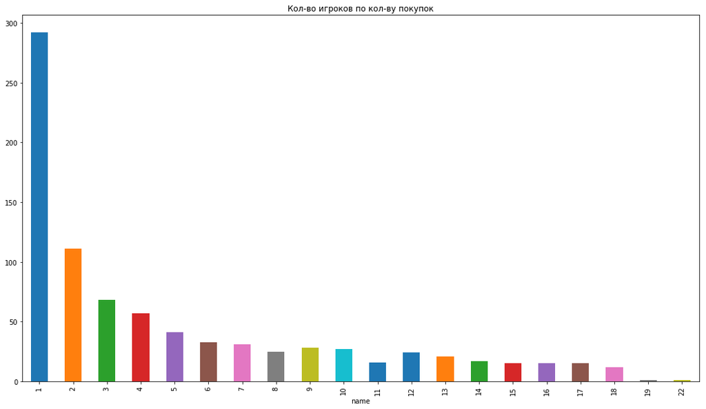

```python
df_temp =df.groupby('user')['name'].count().to_frame()

fig, ax = plt.subplots(figsize=[18, 10])
df_temp.groupby('name')['name'].count().plot(kind='bar', ax=ax)
ax.set_title('Кол-во игроков по кол-ву покупок');
```

- Конверсия между 1 и 2 покупками составляет ~38%, следовательно игроки не получают стимуляцию сделать вторую покупку в полной мере. Здесь могут быть организованы скидки, бонусы, акции.

# Task 5

```python
headers = {0 : 'date',
           1 : 'timestamp',
           2 : 'name',
           3 : 'params_key',
           4 : 'string_value',
           5 : 'int_value',
           6 : 'value_revenue',
           7 : 'user'}

df = pd.read_csv('task_5.csv', encoding = "ISO-8859-1", sep=';', error_bad_lines=False, header=None)
df.rename(columns=headers, inplace=True)
df.info()
```

```
<class 'pandas.core.frame.DataFrame'>
RangeIndex: 440035 entries, 0 to 440034
Data columns (total 8 columns):
date             440035 non-null int64
timestamp        440035 non-null int64
name             440035 non-null object
params_key       440035 non-null object
string_value     440014 non-null object
int_value        21 non-null float64
value_revenue    440035 non-null float64
user             440035 non-null object
dtypes: float64(2), int64(2), object(4)
memory usage: 26.9+ MB
```

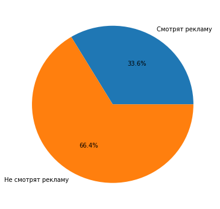

```python
fig, ax = plt.subplots(figsize=[6, 6])
plt.pie(x=[df.groupby('user')['name'].nunique().count(), 383003-df.groupby('user')['name'].nunique().count()],
        labels=['Смотрят рекламу', 'Не смотрят рекламу'], autopct='%1.1f%%');
```

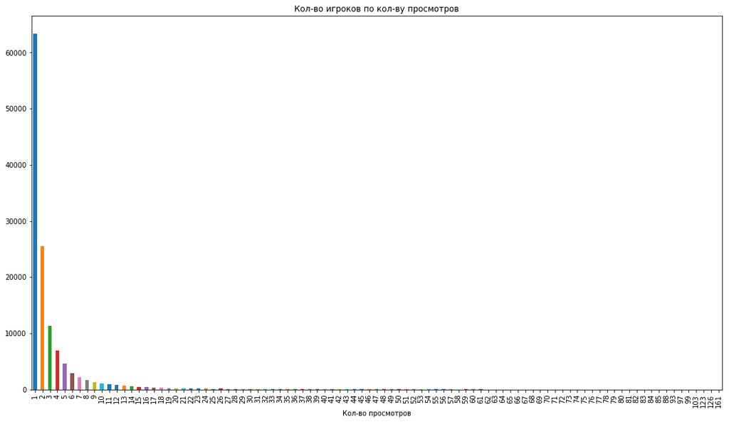

```python
df_temp = df.groupby('user')['name'].count().to_frame()

fig, ax = plt.subplots(figsize=[18, 10])
df_temp.groupby('name')['name'].count().plot(kind='bar', ax=ax)
ax.set_xlabel('Кол-во просмотров')
ax.set_title('Кол-во игроков по кол-ву просмотров');
```

- 33,6% пользователей хотя бы раз посмотрели видео.
- Конверсия между 1 и 2 просмотрами всего ~40%. В абсолютном кол-ве это 13,44%

# Task 6

```python
headers = {0 : 'date',
           1 : 'timestamp',
           2 : 'name',
           3 : 'params_key',
           4 : 'string_value',
           5 : 'int_value',
           6 : 'value_revenue',
           7 : 'user'}

df = pd.read_csv('task_6.csv', encoding = "ISO-8859-1", sep=';', error_bad_lines=False, header=None)
df.rename(columns=headers, inplace=True)
df.info()
```

```
<class 'pandas.core.frame.DataFrame'>
RangeIndex: 13488390 entries, 0 to 13488389
Data columns (total 8 columns):
date             int64
timestamp        int64
name             object
params_key       object
string_value     object
int_value        float64
value_revenue    float64
user             object
dtypes: float64(2), int64(2), object(4)
memory usage: 823.3+ MB
```

```python
df_temp = df.groupby('user')['name'].count().to_frame()
df_temp.groupby('name')['name'].count().sort_index()[:50]
# Потери в уникальных пользователях между кол-вом положительных действий
```

```
name
1     40679
2     10846
3     13365
4     19193
5     16460
6     10938
7     13145
8     14734
9     12853
10    10248
11     9591
12     9451
13     8865
14     8114
```

[output cut: 37 more lines]

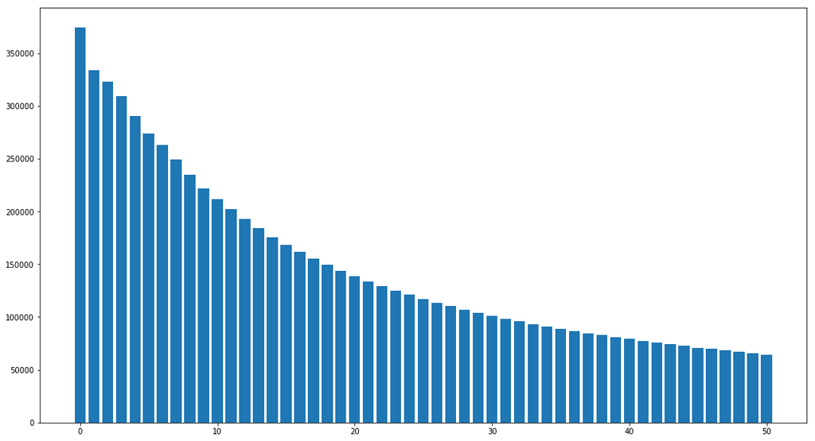

```python
df_temp = df_temp.groupby('name')['name'].count().sort_values(ascending=False).to_frame()


conversion_dict = {}
for i in range(51):
    conversion_dict.update({i+1 : df_temp[df_temp.index > i]['name'].sum()})

fig, ax = plt.subplots(figsize=[18, 10])
plt.bar(list(range(len(conversion_dict))), list(conversion_dict.values()));
```

- Положительными действиями приняты:
  - запуск сессии с интернетом
  - разблокировка контента
  - начало матча
  - просмотр видео
  - трата игровой валюты (монет)
- в первом списке просматриваются потери пользователей по кол-ву положительных действий. Например, 1 положительное действие сделало около 370 000 пользователей, второе положительное действие сделали около 330 000 пользователей (т.е. - 40 000, что ~11% от общего кол-ва)
- далее на графике видны переходы пользователей с увеличение "положительных" действий

###### Лояльных пользователей можно отбирать по такому критерию, как кол-во "положительных" действий в некий период времени, т.к. это напрямую отображает заинтересованность пользователя игрой.